# Markov state models of a 1D trajectory

toni.giorgino@cnr.it - Consiglio Nazionale delle Ricerche

Tue Jan 15 10:11:44 2019

# 1 Markov modeling on a large dataset

This tutorial shows the Markov model-based computation “macroscopic” quantities in a realistic system, simulated with extensive MD.

There are 3 data sets already downloaded for you: * `/mnt/scratch/shared/markov/binding` Ligand binding * `/mnt/scratch/shared/markov/villin` Villin folding * `/mnt/scratch/shared/markov/cxcl12` GPCR conformational transition

We now turn to the files contained in `/mnt/scratch/shared/markov/binding/1/filtered/` (Thrombin binding dataset). This is 1/3 of the full dataset (see directories 2 and 3).

## 1.1 Dataset layout

Each `.xtc` file is one trajectory of 20 ns (200 frames). Frames are spaced 100 ps from each other. Each trajectory is a small piece of the whole simulation set. File names indicate the identity of the trajectory (e.g. `e10s1`) and where it started from (e.g. `e7s5f133` means that the first frame of that configuration was frame 133 of `e7s5`). Water molecules were removed (“filtered”).

```
/mnt/scratch/shared/markov/binding/
    ├── 1
    │   └── filtered
    │       ├── e10s1_e7s5f133
    │       │   └── e10s1_e7s5f133-SDOERR_thrombinLig6x1-0-1-RND6286_9.filtered.xtc
    │       ├── e10s2_e7s5f159
    │       │   └── e10s2_e7s5f159-SDOERR_thrombinLig6x1-0-1-RND8907_9.filtered.xtc
    │       ├── e10s3_e7s5f133
    │       │   └── e10s3_e7s5f133-SDOERR_thrombinLig6x1-0-1-RND5451_9.filtered.xtc
...

            ├── e9s6_e2s5f112
            │   └── e9s6_e2s5f112-SDOERR_thrombinLig6x3-0-1-RND3971_9.filtered.xtc
            ├── filtered.pdb
            └── filtered.psf

860 directories, 858 files
```

## 1.2 Metric calculation

In the previous steps we used PLUMED to compute the three-dimensional position of the inhibitor relative to the target. The distance was computed **after** alignment with a reference structure (to avoid rotational diffusion). The trajectories are identified by the first column.

```r
d<-read.table("metrics.dat",head=F)
names(d) <- c("TrajLong","Frame","X","Y","Z")
d$Traj <- sub("_.+$","",d$TrajLong)  # Shorten the trajectory name
d$Traj <- factor(d$Traj)
d$TrajLong <- NULL

head(d)
```

```
##   Frame         X         Y        Z  Traj
## 1     0 -0.224091 -11.88661 1.973588 e36s5
## 2     1 -0.413809 -12.03890 1.644167 e36s5
## 3     2 -0.532973 -12.32398 2.144003 e36s5
## 4     3 -0.300480 -11.36355 1.903810 e36s5
## 5     4 -0.433555 -11.79203 2.057442 e36s5
## 6     5 -0.386437 -11.78388 1.571578 e36s5
```

We plot a few of them. Extract the first trajectory for visualization.

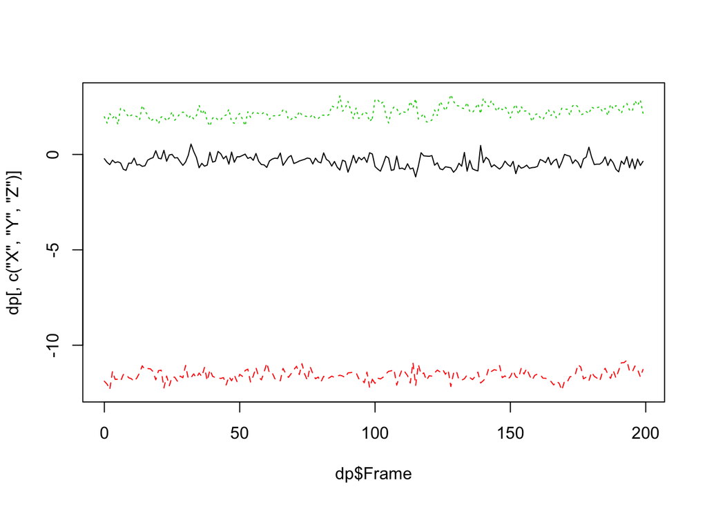

```r
dp <- subset(d,d$Traj == "e36s5")
matplot(dp$Frame, dp[,c("X","Y","Z")], type="l")
```

…and the second…

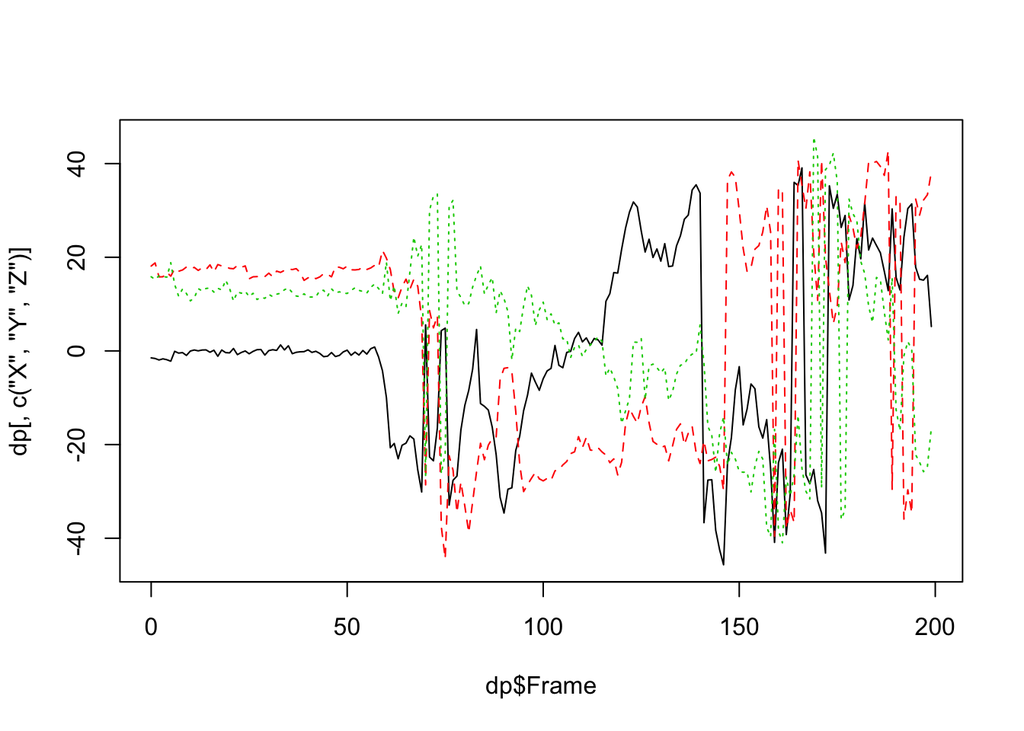

```r
dp <- subset(d,d$Traj == "e12s5")
matplot(dp$Frame, dp[,c("X","Y","Z")], type="l")
```

## 1.3 Clustering

Before we proceed, we need to move from the N-dimensional space of continuous coordinates (in this case 3D) to a discrete “microstate”. This is achieved by clustering. Of several algorithms, we use k-means. The Markov model will approximate the “jumping” process between those states.

```r
K <- 100
ustates <- kmeans(d[,c("X","Y","Z")],   K)
d$Microstate <- factor(ustates$cluster)
lab <- 1:K
```

This is how microstates distribution looks in the XY plane.

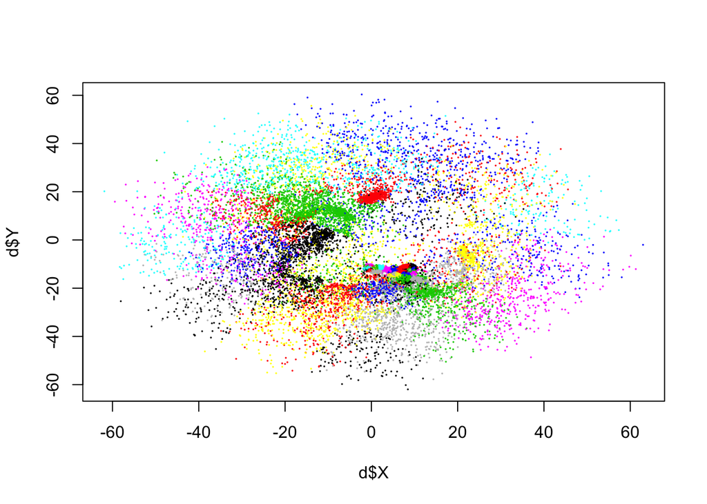

```r
plot(d$X,d$Y,cex=.1,col=d$Microstate)
```

Also in 3D (don’t worry if it doesn’t work)

```r
#install.packages("rgl")
library(rgl)
plot3d(d$X,d$Y,d$Z,
       aspect=T,col=d$Microstate)
```

We can gather statistics on the microstates

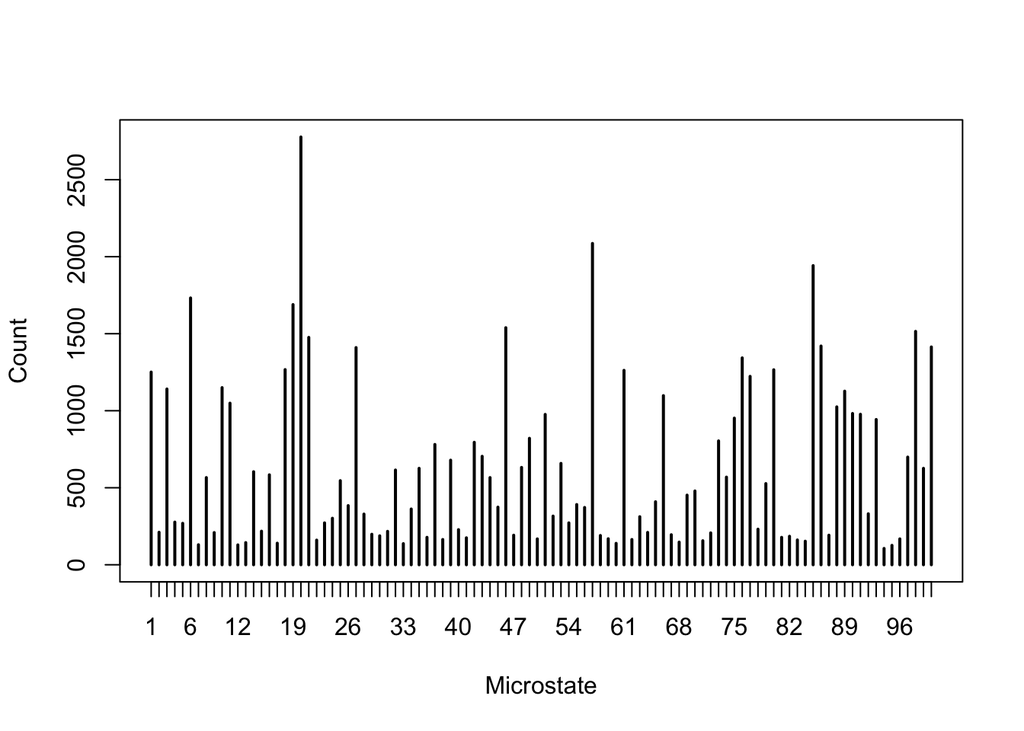

```r
h<-table(d$Microstate)

plot(h, xlab="Microstate", ylab = "Count")
```

Boltzmann inversion (note that $k_B T \simeq 0.6$ kcal/mol) returns the $\Delta G$ (up to an irrelevant additive constant). Too many microstates to have a clear picture.

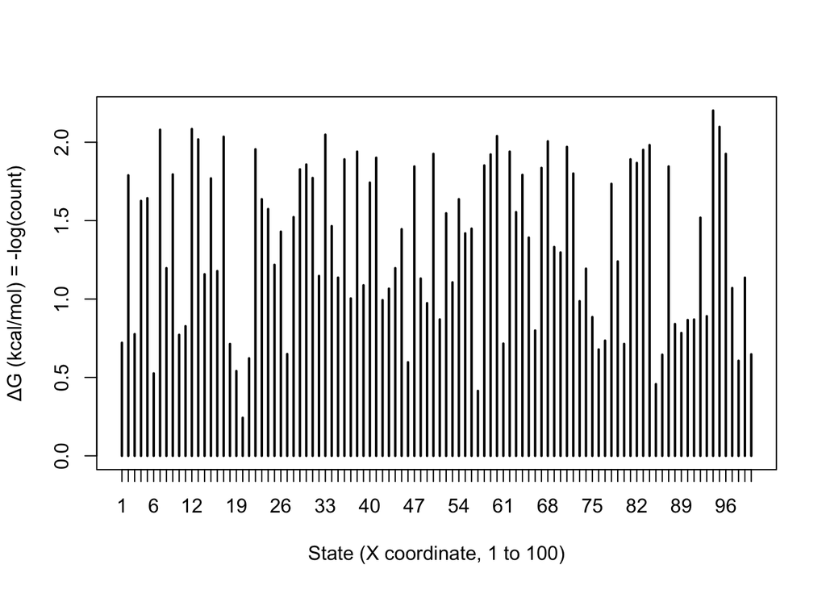

```r
plot(5-.6*log(h),
     xlab="State (X coordinate, 1 to 100)",
     ylab="ΔG (kcal/mol) = -log(count)"
     )
```

Let’s look at the most visited microstate.

```r
max(h)
```

```
## [1] 2777
```

```r
which.max(h)
```

```
## 20
## 20
```

```r
dmost <- subset(d,Microstate==which.max(h))

tmp<-table(dmost$Traj)
tmp[tmp>0]
```

```
##
## e11s4 e13s3 e14s1 e14s2 e15s1 e15s2 e15s5 e16s1 e16s2 e16s3 e16s5 e17s1
##    63   147   125    81   135    19    20    78   116    76   142    92
## e18s2 e18s3 e18s4 e20s1 e20s2 e20s3 e22s2 e22s3 e22s4 e22s5 e23s1 e23s2
##    39    84   103    41   116    29   152    99    58   107    71   121
## e23s5 e24s4 e24s5 e40s2 e43s3 e49s1 e54s5 e55s3 e56s1 e56s6 e57s4 e58s4
##    24   123   122    28     9     1    90    60     1     2    54   148
## e59s1
##     1
```

# 2 Markov state modeling

## 2.1 Construction of the transition matrix

We compute how many times each state to state ($i\to j$) transition has occurred *after a lag time of $\tau$*. We need to treat the trajectories separately (tapply).

```r
tau <- 10

TT.list <-
tapply(d$Microstate, d$Traj, function(x) {
            table( head(x,-tau),
                   tail(x,-tau),exclude=NULL)
    } )
```

Then aggregate them by summing the independent transition count matrix, one per trajectory.

```r
TT <- TT.list[[1]]*0
for (m in TT.list) {
    TT <- TT+m
}
```

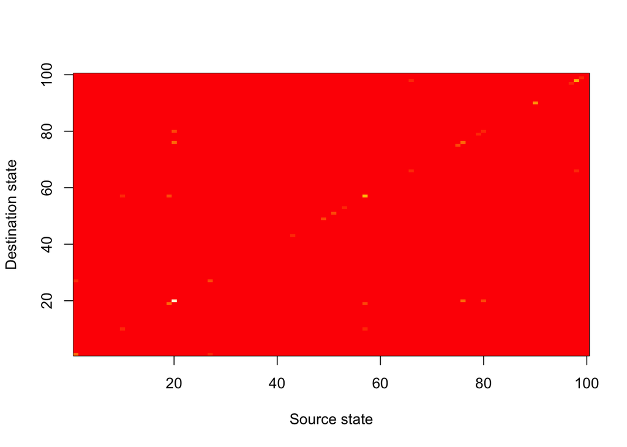

```r
image(lab,lab,TT,
      xlab="Source state",ylab="Destination state")
```

We divide each row of the transition count matrix so that they sum to unity. We thus obtain the transition *probability* matrix. Note that, for simplicity, this is a simplified treatment in the following respects: (1) one should take care of reversibility, (2) use a maximum-likelihood estimator, and (3) deal properly with zero counts (which cause singularities).

Here I am adding a small *pseudocount* to all counts to avoid null cells.

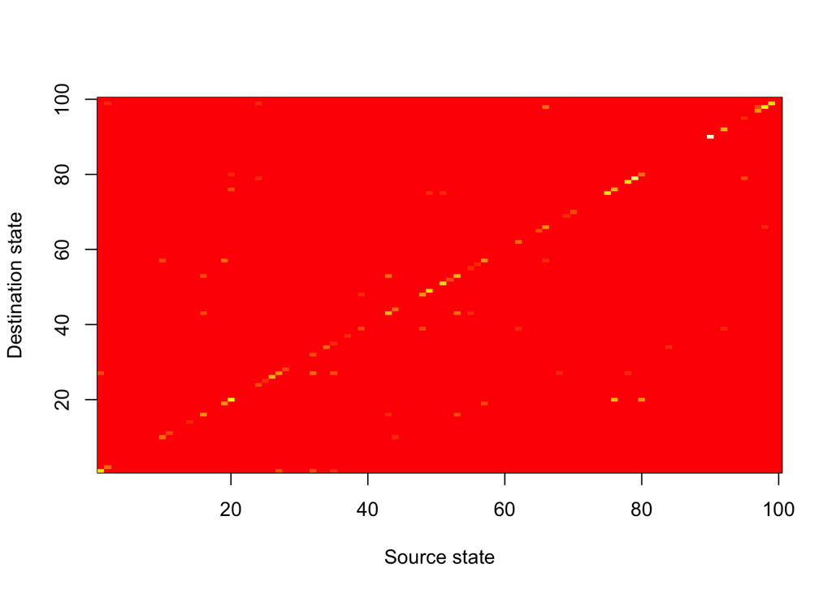

```r
pseudocount <- 0.01
sum1 <- function(x) (x/sum(x))
P <- t(apply(TT+pseudocount,2,sum1 ))
image(lab,lab,P,
      xlab="Source state",ylab="Destination state")
```

## 2.2 Eigenvalues

From the transition probability matrix **at lag $\tau$** we compute the *left* eigenvectors and eigenvalues.

The eigenvalues correspond to the relaxation rates towards equilibrium. The largest eigenvalue is unity, corresponding to the stationary state.

Eigenvalues describe the negative *exponential* relaxation time scales, in units of $\tau$. Therefore, the should be converted to “normal” time units throught the *implied time scales* (ITS) equation, i.e.:

$$\tau_i = -\tau/\log(\mu_i)$$

where $\tau_i$ is the $i$-th implied time scale and $\mu_i$ the corresponding eigenvalue.

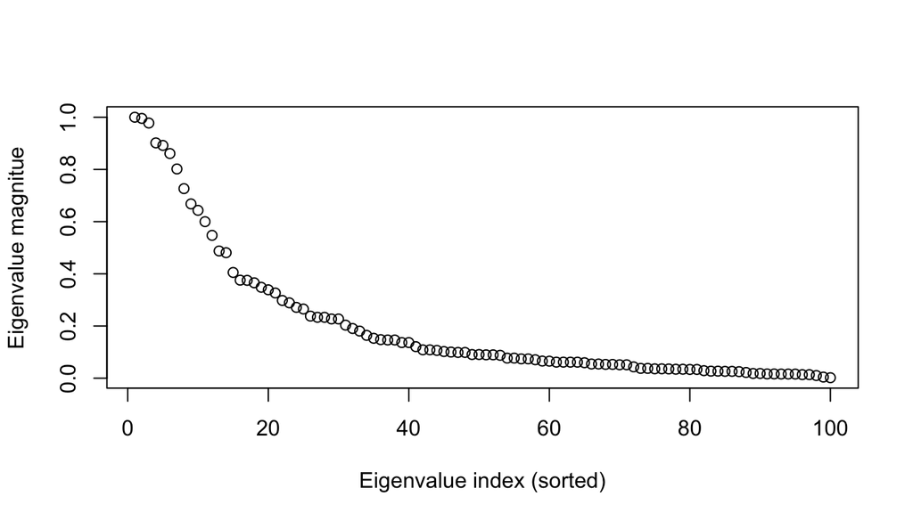

```r
ei <- eigen(t(P))
eva <- sort(abs(ei$values),decreasing = T)
eve <- ei$vectors

taus <- -tau/log(eva[-1])

plot(eva,ylab="Eigenvalue magnitue",xlab="Eigenvalue index (sorted)")
```

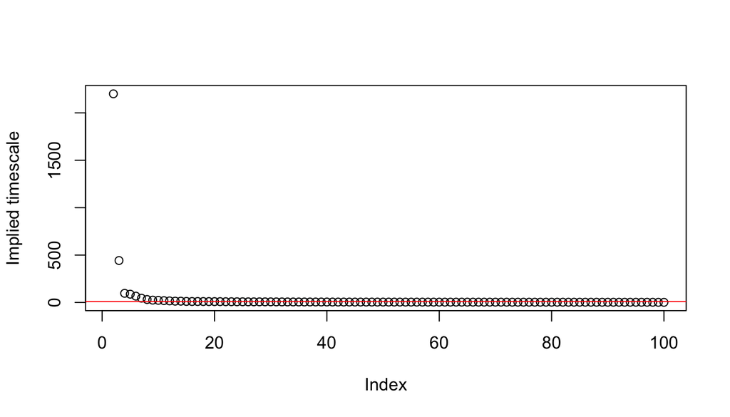

```r
plot(c(NA,taus),ylab="Implied timescale")
abline(h=tau,col="red")
```

Given the spread of timescales is usually large, we plot them in logarithmic scale.

Kinetics faster than $\tau$ can **not** be resolved by construction of the transition matrix.

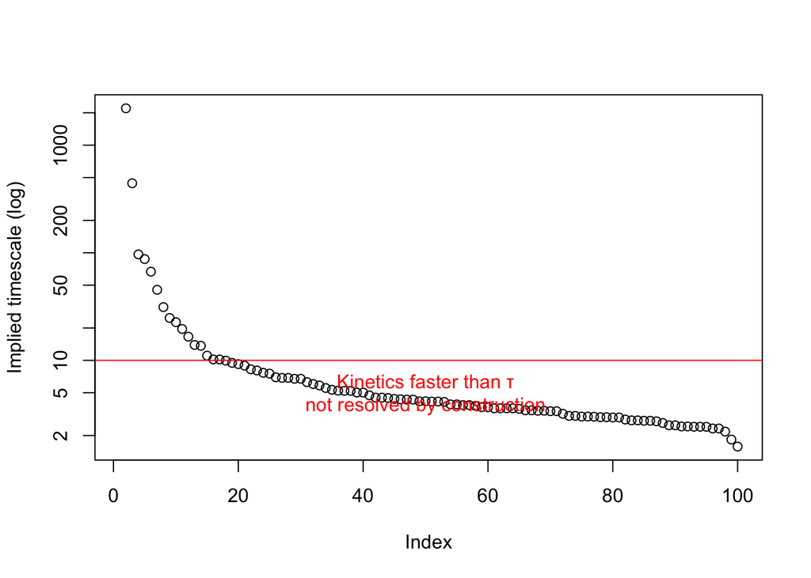

```r
plot(c(NA,taus),ylab="Implied timescale (log)",log="y")
abline(h=tau,col="red")
text(50,5,"Kinetics faster than τ\nnot resolved by construction",
     col="red")
```

## 2.3 Eigenvectors

Eigenvectors matching a given eigenvalue describe the “contribution” of each state to that relaxation mode. The eigenvector of the unitary eigenvalue is the stationary distribution, i.e. the equilibrium (after normalizing it so it sums to 1). Its Boltzmann inversion provides the free energy landscape.

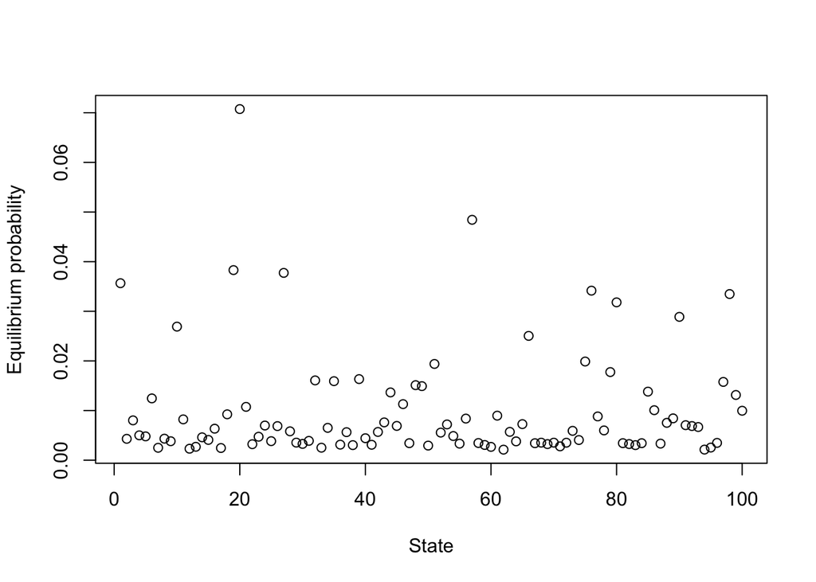

```r
ev0 <- abs(eve[,1])
ev0dg <- -log(ev0)+max(log(ev0))-2

plot(lab,sum1(ev0),
     xlab="State",ylab="Equilibrium probability")
```

Where shall we find the most probable state?

```r
subset(d,Microstate==which.max(ev0))
```

```
##       Frame        X         Y        Z  Traj Microstate
## 1002      1 8.283634 -12.32476 4.221495 e16s2         20
## 1005      4 8.498862 -11.99613 4.085654 e16s2         20
## 1006      5 8.525378 -12.16024 3.437946 e16s2         20
## 1007      6 8.381968 -12.24893 3.659223 e16s2         20
## 1008      7 8.272057 -11.92181 3.153499 e16s2         20
## 1010      9 8.757179 -12.31073 3.821895 e16s2         20
## 1013     12 8.864507 -12.21264 3.421129 e16s2         20
## 1014     13 8.187538 -12.19253 3.246131 e16s2         20
## 1015     14 8.151588 -12.29582 3.849619 e16s2         20
## 1016     15 8.593868 -12.44178 3.791634 e16s2         20
## 1017     16 8.684510 -11.93015 3.328937 e16s2         20
## 1019     18 8.800758 -12.32762 3.593705 e16s2         20
## 1020     19 8.376326 -12.00230 3.784848 e16s2         20
## 1021     20 8.760625 -12.00319 3.614013 e16s2         20
```

[output cut: 2763 more lines]

The other eigenvector describe the “wave” of the relaxation (at the matching implied timescale).

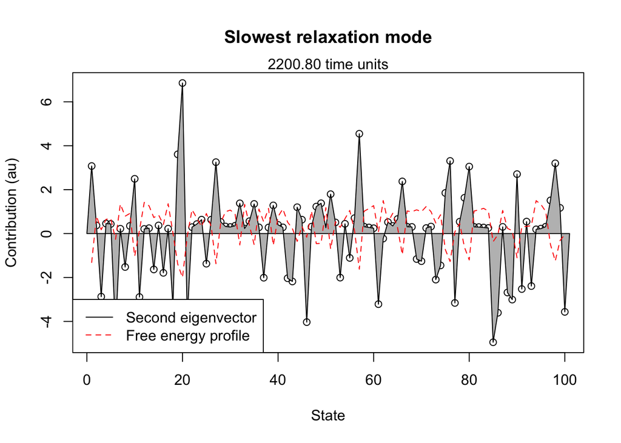

```r
ev1 <- 2*scale(Re(eve[,2]))
plot(lab,ev1,
     xlab="State",ylab="Contribution (au)",
     main="Slowest relaxation mode")
polygon(c(0,lab,K+1),c(0,ev1,0),col="gray")
#lines(lab,sum1(ev0)*20,col="red",lty=2)
lines(lab,ev0dg,col="red",lty=2)
mtext(sprintf("%.2f time units",taus[1]),3)
legend("bottomleft",col=1:2,lty=1:2,
       c("Second eigenvector",
         "Free energy profile"))
```

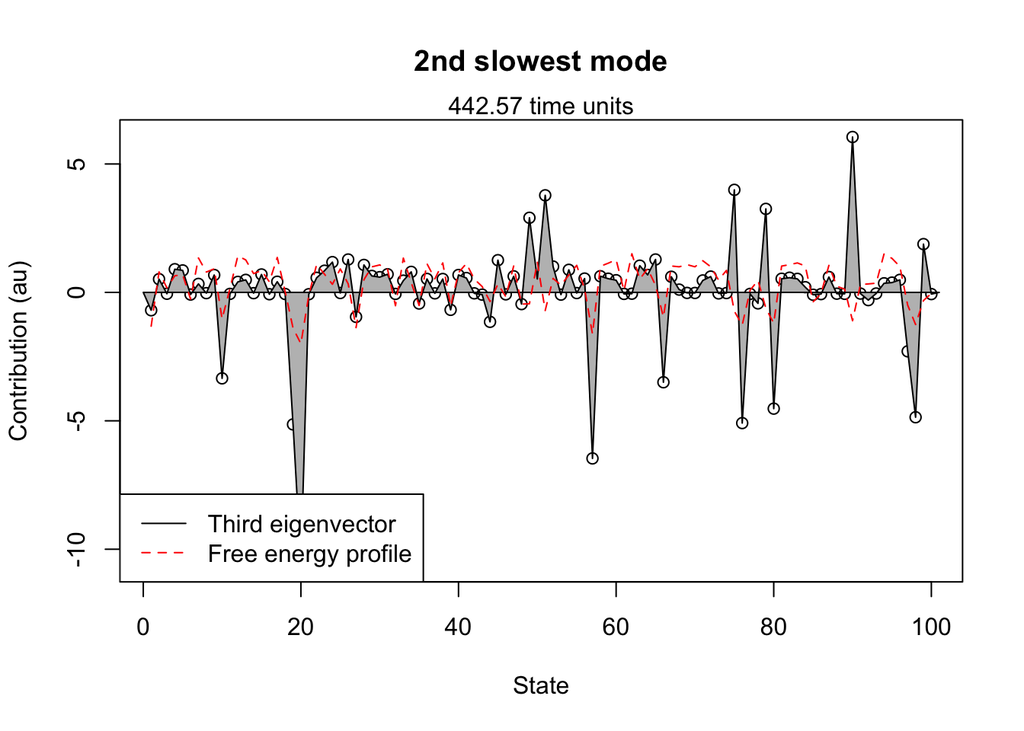

```r
ev2 <- 2*scale(Re(eve[,3]))
plot(lab,ev2,
     xlab="State",ylab="Contribution (au)",
     main="2nd slowest mode")
polygon(c(0,lab,K+1),c(0,ev2,0),col="gray")
lines(lab,ev0dg,col="red",lty=2)
legend("bottomleft",col=1:2,lty=1:2,
       c("Third eigenvector",
         "Free energy profile"))
mtext(sprintf("%.2f time units",taus[2]),3)
```

The shape of the eigenvectors suggests a clustering into coarser-grained macrostates. This constitutes the gist of the Perron-cluster analysis (PCCA+).

## 2.4 Choice of the lag time

Remember that the transition matrix was, by construction, **a function of $\tau$**. Therefore, the whole eigenvector analysis shown before should be repeated at increasing values of $\tau$ to study its sensitivity.

We pick the smallest $\tau$ such that the implied timescales are effectively “flat”. Again, the literature provides much more sophisticated statistical tests on the Markovianity assumption (e.g. Chapman-Kolmogorov). See e.g. [PyEmma’s Model selection and validation](http://www.emma-project.org/latest/generated/model_selection_validation.html) tutorial.

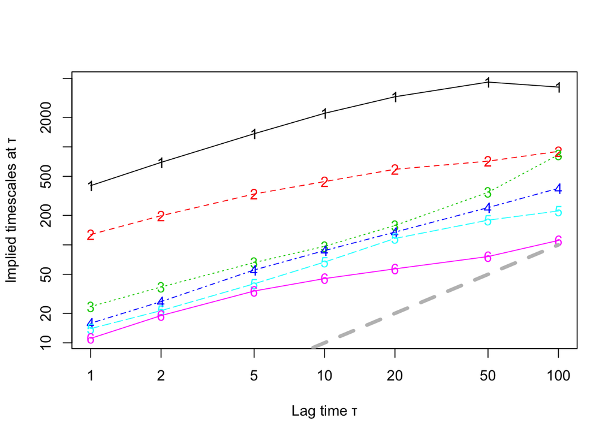

```r
evanalysis <- function(tau) {

    TT.list <-
    tapply(d$Microstate, d$Traj, function(x) {
            table( head(x,-tau),
                   tail(x,-tau),exclude=NULL)
    } )
    TT <- TT.list[[1]]*0
    for (m in TT.list) {
        TT <- TT+m
    }
    TT <- TT+pseudocount

    P <- t(apply(TT,2,sum1 ))
    ei <- eigen(t(P))
    eva <- sort(abs(ei$values),decreasing = T)
    eve <- ei$vectors
    taus <- -tau/log(eva[-1])
    list(eva=eva,eve=eve,taus=taus)
}

lag_list <- c(1,2,5,10,20,50,100)

ntaus <- 6 # Consider this many eigenvectors
tau_matrix <- matrix(0,length(lag_list),ntaus)
li <- 1
for(lag in lag_list) {
    etaus <- evanalysis(lag)$taus
    tau_matrix[li,] <- head(etaus,ntaus)
    li <- li+1
}

matplot(lag_list,tau_matrix,type="o",log="xy",
        xlab="Lag time τ",ylab="Implied timescales at τ")
lines(1:100,1:100,lwd=4,col="grey",lty=2)
```

So in this case the microstate discretization is not good enough. We need to try one of those

- Better starting variables (e.g. include orientation)
- Use of TICA
- Perform an higher level (macro-state) clustering

All of this complex to implement from scratch. It is better to use specialized packages such as the ones we’ll see in the next part.